# Exploratory Data Analysis of Drug Use Data

Christopher McLeod

17 November 2017

## Qu 1

### (a).

The below plots a stacked bar graph comparing use levels (high or low) against the country, using geom_bar.

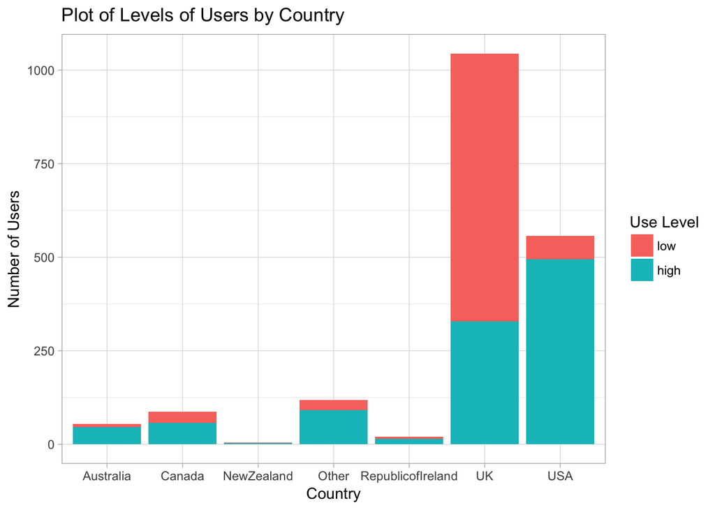

```r
ggplot(druguse, aes(x=country, fill = UseLevel)) + geom_bar() +
        xlab("Country") + ylab("Number of Users") +
        ggtitle("Plot of Levels of Users by Country") +
        scale_fill_discrete(name="Use Level") +
        theme_light()
```

A table details the count of high/low users by country (make percentages)

```r
x <- table(druguse$country, druguse$UseLevel)
x <- cbind(x,signif(prop.table(x,margin=1)*100,3))
colnames(x)[c(3,4)] <- c('(%) low','(%) high')
kable(x)
```

|  | low | high | (%) low | (%) high |
| --- | --- | --- | --- | --- |
| Australia | 8 | 46 | 14.8 | 85.2 |
| Canada | 30 | 57 | 34.5 | 65.5 |
| NewZealand | 1 | 4 | 20.0 | 80.0 |
| Other | 27 | 91 | 22.9 | 77.1 |
| RepublicofIreland | 5 | 15 | 25.0 | 75.0 |
| UK | 716 | 328 | 68.6 | 31.4 |
| USA | 62 | 495 | 11.1 | 88.9 |

From the above we can see that most of our data comes from the UK. It’s also clear that the US is the country with the highest proportion of high-use-level users in the dataset, while the UK is the lowest.

Now the same is done to produce a graph of gender against count of use level, filled by high or low levels.

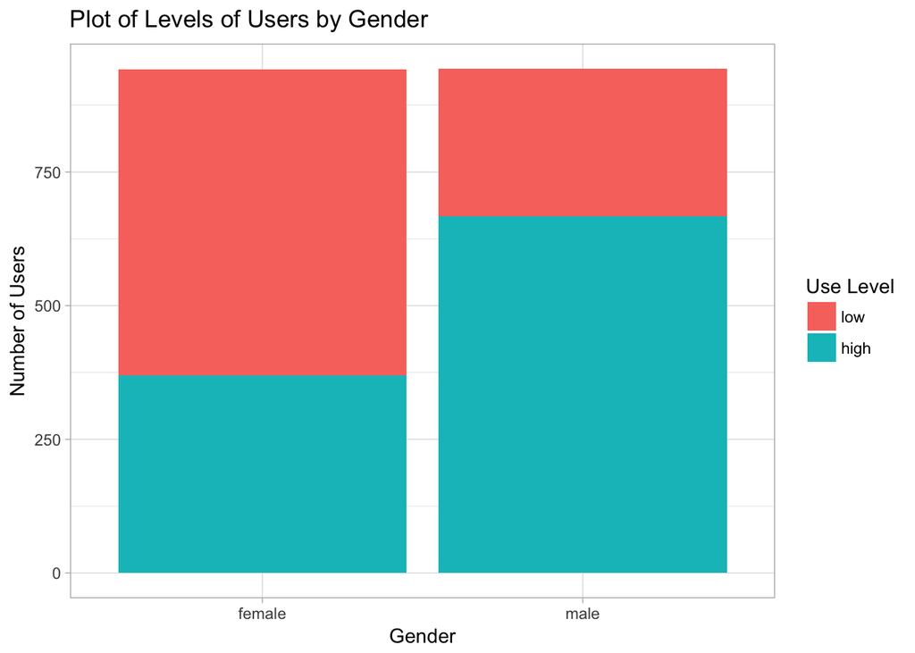

```r
ggplot(druguse, aes(x = gender, fill = UseLevel)) + geom_bar() +
        xlab("Gender") + ylab("Number of Users") +
        ggtitle("Plot of Levels of Users by Gender") +
        scale_fill_discrete(name="Use Level") +
        theme_light()
```

A table details the count of high/low users by gender

```r
y = table(druguse$gender, druguse$UseLevel)
y <- cbind(y,signif(prop.table(y,margin=1)*100,3))
colnames(y)[c(3,4)] <- c('(%) low','(%) high')
kable(y)
```

[output not shown]

### (b).

Given the many variables in the dataset we can look at some interesting corelations. For example, how do one’s impulsiveness and how open to experience one is relate to one’s use level? This can be explored by letting `opentoexperience` vary with `impulsive` and inspecting when users use-levels are high or low. This is done below, displayed as a jitter plot.

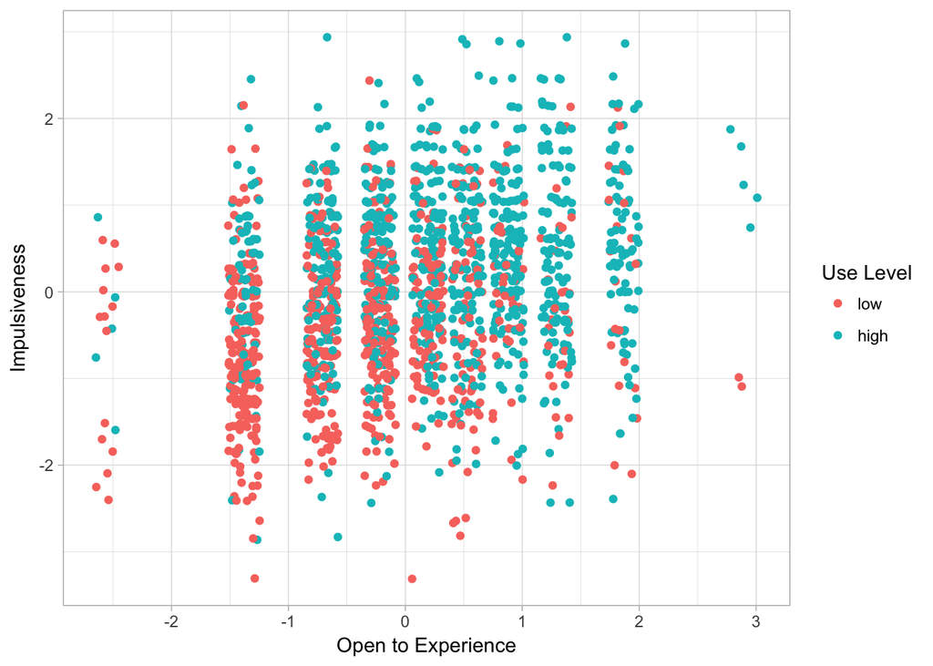

```r
ggplot(druguse, aes(impulsiveness, opentoexperience)) +
      geom_jitter(mapping=aes(x=impulsiveness, y=opentoexperience, color=factor(UseLevel))) +
      xlab("Open to Experience") + ylab("Impulsiveness") +
      scale_color_discrete(name="Use Level") +
      theme_light()
```

From this one might infer that having a high measurement for both variables might predispose one to a high drug use-level. Clearly there is a correlation to support this hypothesis. The proportion of high-use-level users with positive readings for `opentoexperience` and `impulsiveness` is

```r
open.impulse <- length(which((druguse$UseLevel=='high')& (druguse$opentoexperience>0)&(druguse$impulsiveness>0))) /length(which((druguse$opentoexperience>0)&(druguse$impulsiveness>0)))

print(paste("Proportion of high with open>0 and impulse>0 = ", open.impulse))
```

```
## [1] "Proportion of high with open>0 and impulse>0 =  0.783018867924528"
```

which is quite large. And individually the proportion of high-use-level users with either measure bigger than zero are significant as well

```r
open <- length(which((druguse$UseLevel=='high')& (druguse$opentoexperience>0))) /length(which((druguse$opentoexperience>0)))
impulse <-length(which((druguse$UseLevel=='high')&(druguse$impulsiveness>0))) /length(which((druguse$impulsiveness>0)))

print(paste("Proportion of high with open>0 = ", open))
```

```
## [1] "Proportion of high with open>0 =  0.719101123595506"
```

```r
print(paste("Proportion of high with impulse>0 = ", impulse))
```

```
## [1] "Proportion of high with impulse>0 =  0.68824163969795"
```

In part (a). We saw that the USA reported the highest proportion of high-use-level users. From this we might seek to ask *What’s the USA’s most popular drug?* Further, we can also inquire, *with which generation are these regularly used drugs most popular?*

```r
# take the age part of the drug use df and all the drug records
filter_age.usa = druguse[druguse$country=="USA",][,c(1,17:30)]
# melt the results into 3 melting the drug types into one column and values into another corresponding column
age.usa = melt(filter_age.usa)
```

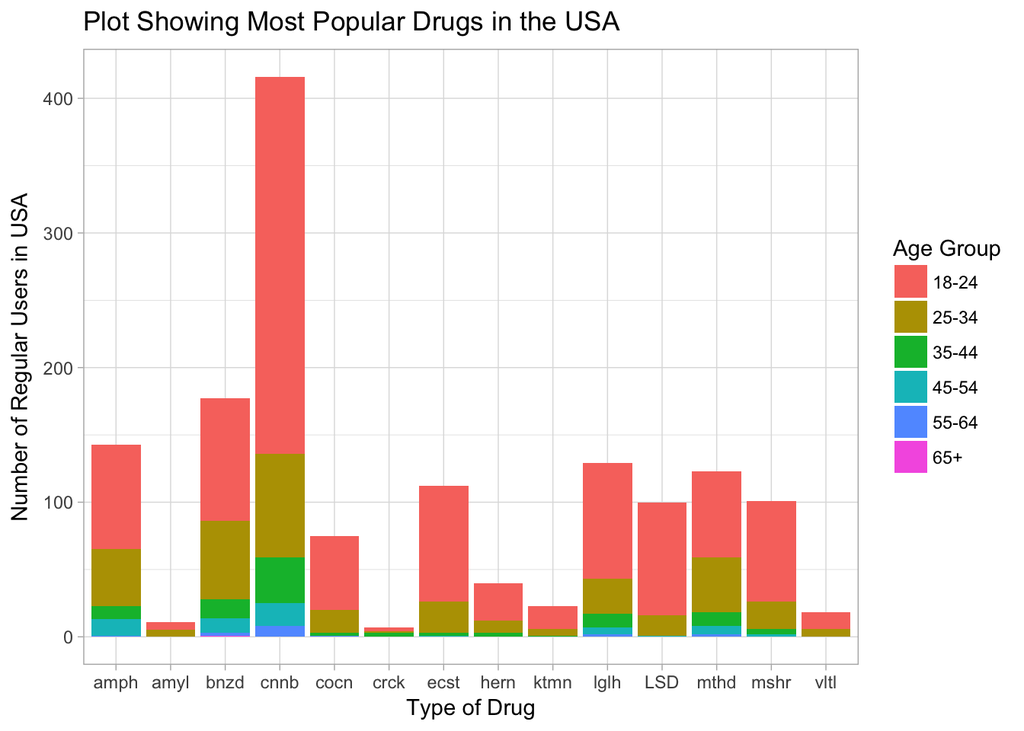

```r
# make the condition that the drug of choice is being used at least once a month
age.usa_reg = age.usa[age.usa$value>3,]


ggplot(age.usa_reg, aes(x=variable, fill=agegroup)) +
        geom_bar() +
        xlab("Type of Drug") + ylab("Number of Regular Users in USA") +
        ggtitle("Plot Showing Most Popular Drugs in the USA") +
        scale_fill_discrete(name="Age Group") +
        scale_x_discrete(labels = abbreviate) +
        theme_light()
```

We immediately see the USA’s most popular regularly used drug is cannabis by a long way. It is popularised among those 18-24, and is (relative to other drug use) even still fairly popular for those 25-34. Across all listed drugs, those 18-24 make up the greatest group of regular users in the US, making them the most active age group. This can be seen to be true in the folowing table

```r
x <- table(age.usa_reg$variable, age.usa_reg$agegroup)
kable(x)
```

|  | 18-24 | 25-34 | 35-44 | 45-54 | 55-64 | 65+ |
| --- | --- | --- | --- | --- | --- | --- |
| amphetamine | 78 | 42 | 10 | 12 | 1 | 0 |
| amylnitrite | 6 | 5 | 0 | 0 | 0 | 0 |
| benzodiaz | 91 | 58 | 14 | 11 | 2 | 1 |
| cannabis | 280 | 77 | 34 | 17 | 8 | 0 |
| cocaine | 55 | 17 | 2 | 0 | 1 | 0 |
| crack | 3 | 1 | 3 | 0 | 0 | 0 |
| ecstasy | 86 | 23 | 2 | 1 | 0 | 0 |
| heroin | 28 | 9 | 3 | 0 | 0 | 0 |
| ketamine | 17 | 5 | 1 | 0 | 0 | 0 |
| legalhighs | 86 | 26 | 10 | 5 | 2 | 0 |
| LSD | 84 | 15 | 0 | 1 | 0 | 0 |
| methadone | 64 | 41 | 10 | 6 | 2 | 0 |
| mushrooms | 75 | 20 | 4 | 2 | 0 | 0 |
| volatiles | 12 | 6 | 0 | 0 | 0 | 0 |

The only drug that people of the age 65+ are regularly using in the US is Benzodiaz. Benzodiaepine diazepam (valium) - pain & sedation. So one can most likely conclude that generally those of age 65+ are not involved in recreational drug use in the US, at least not for the current dataset.The more general trend we see is that agegroup and severity (the measure of ones use of drugs) are inversely proportional.

The gender plot/table also seem to highlight a huge divide between those with high and low use levels. As we saw, around 71% of males identified as having high use levels, compared to the 39% of females. We can look by age group and find out the severity of the usage across the genders

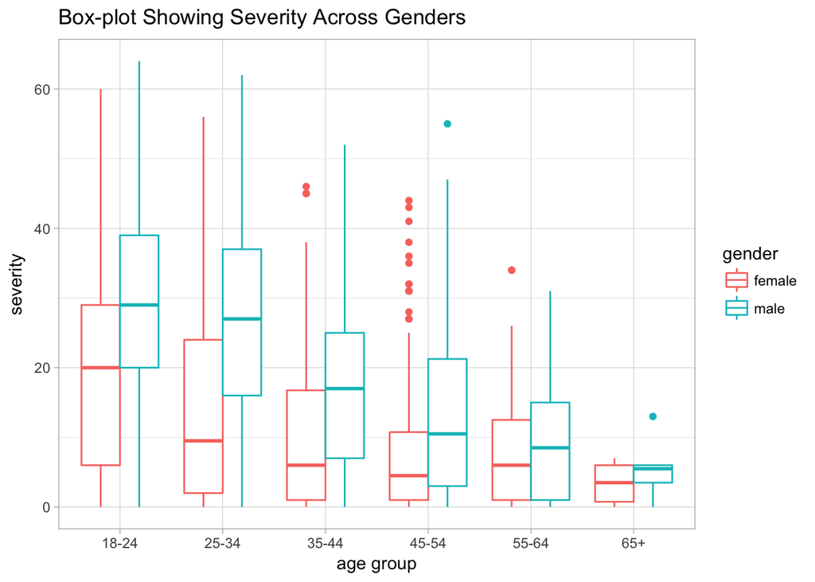

```r
ggplot(data = druguse, aes(x=agegroup,y=severity, color = gender)) + geom_boxplot() +
       xlab("age group") + ylab("severity") +
      ggtitle("Box-plot Showing Severity Across Genders") +
      scale_fill_discrete(name="Gender") +
      theme_light()
```

We see that males in our dataset also have higher means and quartile readings for sensitivity in almost all agegroups.